# Interfaces

In Nipype, interfaces are python modules that allow you to use various external packages (e.g. FSL, SPM or FreeSurfer), even if they themselves are written in another programming language than python. Such an interface knows what sort of options an external program has and how to execute it.

A major motivating objective for Nipype is to streamline the integration of different analysis packages, so that you can use the algorithms you feel are best suited to your particular problem. It provides a unified representation of interfaces across analysis packages.

```python
%pwd  #look at the current work dir
```

```
'/Users/hanningsu/Desktop/Nipype_Tutorial/Interfaces'
```

```python
from nilearn.plotting import plot_anat
%matplotlib inline
```

## We look at a certain image from our dataset

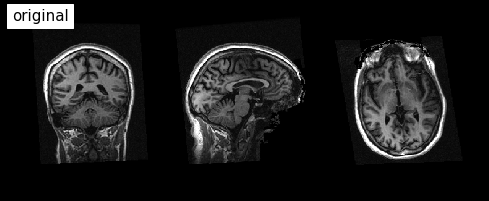

```python
plot_anat('/Users/hanningsu/Desktop/Nipype_Tutorial/data/ds000114/sub-01/ses-test/anat/sub-01_ses-test_T1w.nii.gz', title='original',
         display_mode="ortho", dim=-1, draw_cross=False, annotate=False);
```

## Basically we produce certain output and store it inside the output folder, (using bash code)

```python
%%bash

FILENAME=/Users/hanningsu/Desktop/Nipype_Tutorial/data/ds000114/sub-01/ses-test/anat/sub-01_ses-test_T1w

BET ${FILENAME}.nii.gz /Users/hanningsu/Desktop/Nipype_Tutorial/Interfaces/output/sub-01_ses-test_T1w_bet.nii.gz
```

```
<nilearn.plotting.displays.OrthoSlicer at 0x7f936d18f910>
```

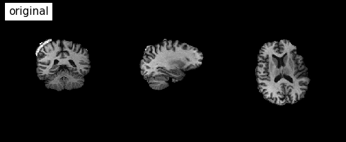

```python
plot_anat('/Users/hanningsu/Desktop/Nipype_Tutorial/Interfaces/output/sub-01_ses-test_T1w_bet.nii.gz', title='original',
         display_mode='ortho', dim=-1, draw_cross=False, annotate=False)
```

Get help: As is the case for all FSL binaries, just call it with the help flag -h to see all its outputs.

```python
!bet -h
```

```
Usage:    bet <input> <output> [options]

Main bet2 options:
  -o          generate brain surface outline overlaid onto original image
  -m          generate binary brain mask
  -s          generate approximate skull image
  -n          don't generate segmented brain image output
  -f <f>      fractional intensity threshold (0->1); default=0.5; smaller values give larger brain outline estimates
  -g <g>      vertical gradient in fractional intensity threshold (-1->1); default=0; positive values give larger brain outline at bottom, smaller at top
  -r <r>      head radius (mm not voxels); initial surface sphere is set to half of this
  -c <x y z>  centre-of-gravity (voxels not mm) of initial mesh surface.
  -t          apply thresholding to segmented brain image and mask
  -e          generates brain surface as mesh in .vtk format

Variations on default bet2 functionality (mutually exclusive options):
  (default)   just run bet2
  -R          robust brain centre estimation (iterates BET several times)
  -S          eye & optic nerve cleanup (can be useful in SIENA - disables -o option)
  -B          bias field & neck cleanup (can be useful in SIENA)
  -Z          improve BET if FOV is very small in Z (by temporarily padding end slices)
  -F          apply to 4D FMRI data (uses -f 0.3 and dilates brain mask slightly)
  -A          run bet2 and then betsurf to get additional skull and scalp surfaces (includes registrations)
  -A2 <T2>    as with -A, when also feeding in non-brain-extracted T2 (includes registrations)

Miscellaneous options:
  -v          verbose (switch on diagnostic messages)
  -h          display this help, then exits
  -d          debug (don't delete temporary intermediate images)
```

We see that BET can also return a binary brain mask as a result of the skull-strip, which can be useful for masking our GLM analyses (among other things). Let's run it again including that option and see the result.

```python
%%bash

FILENAME=/Users/hanningsu/Desktop/Nipype_Tutorial/data/ds000114/sub-01/ses-test/anat/sub-01_ses-test_T1w

BET ${FILENAME}.nii.gz /Users/hanningsu/Desktop/Nipype_Tutorial/Interfaces/output/sub-01_ses-test_T1w_bet.nii.gz -m
```

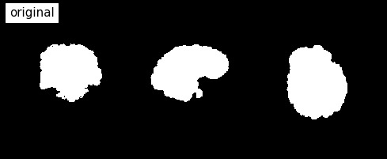

```python
plot_anat('/Users/hanningsu/Desktop/Nipype_Tutorial/Interfaces/output/sub-01_ses-test_T1w_bet_mask.nii.gz', title='original',
         display_mode='ortho', dim=-1, draw_cross=False, annotate=False);
```

# BET in the Nipype framework

So how can we run BET in the Nipype framework?

First things first, we need to import the BET class from Nipype's Interface module.

```python
from nipype.interfaces.fsl import BET
```

Now that we have the BET function accessible, we just have to specify the input and output file. And finally we have to run the command. So exactly like in the original framework.

```python
skullstrip = BET()
skullstrip.inputs.in_file = "/Users/hanningsu/Desktop/Nipype_Tutorial/data/ds000114/sub-01/ses-test/anat/sub-01_ses-test_T1w.nii.gz"
skullstrip.inputs.out_file = "/Users/hanningsu/Desktop/Nipype_Tutorial/Interfaces/output/T1w_nipype_bet.nii.gz"
res = skullstrip.run()
```

If we now look at the results from Nipype, we see that it is exactly the same as before.

```
<nilearn.plotting.displays.OrthoSlicer at 0x7f9378221eb0>
```

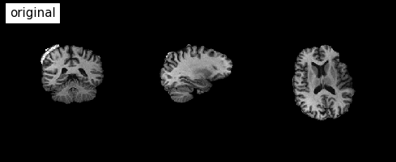

```python
plot_anat('/Users/hanningsu/Desktop/Nipype_Tutorial/Interfaces/output/T1w_nipype_bet.nii.gz', title="original",
         display_mode="ortho", dim=-1, draw_cross=False, annotate=False)
```

Nipype used exactly the same bash code that we were using in the original framework example above. To verify this, we can call the cmdline function of the constructed BET instance.

```python
print(skullstrip.cmdline)
```

[output not shown]

Another way to set the inputs on an interface object is to use them as keyword arguments when you construcuted the interface instance. Let's write the Nipype code from above in this way, but let's also add the option to create a brain mask.

```python
skullstrip = BET(in_file="/Users/hanningsu/Desktop/Nipype_Tutorial/data/ds000114/sub-01/ses-test/anat/sub-01_ses-test_T1w.nii.gz",
                out_file="/Users/hanningsu/Desktop/Nipype_Tutorial/Interfaces/output/T1w_nipype_bet.nii.gz",
                 mask=True)
res = skullstrip.run()
```

```
<nilearn.plotting.displays.OrthoSlicer at 0x7f93380ff190>
```

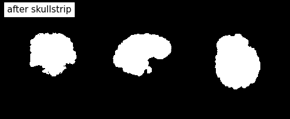

```python
plot_anat('/Users/hanningsu/Desktop/Nipype_Tutorial/Interfaces/output/T1w_nipype_bet_mask.nii.gz', title='after skullstrip',
         display_mode="ortho", dim=-1, draw_cross=False, annotate=False)
```

So here we see that Nipype also has output parameters. This is very practical. Because instead of typing the full path name to the mask volume, we can also more directly use the mask_file parameter.

```python
print(res.outputs.mask_file)
```

```
/Users/hanningsu/Desktop/Nipype_Tutorial/Interfaces/output/T1w_nipype_bet_mask.nii.gz
```

# Help function

In the Nipype framework we can achieve the same thing by using the help() function on an interface class. For the BET example. This is:

```python
BET.help()
```

```
Wraps the executable command ``bet``.

FSL BET wrapper for skull stripping

For complete details, see the `BET Documentation.
<https://fsl.fmrib.ox.ac.uk/fsl/fslwiki/BET/UserGuide>`_

Examples
--------
>>> from nipype.interfaces import fsl
>>> btr = fsl.BET()
>>> btr.inputs.in_file = 'structural.nii'
>>> btr.inputs.frac = 0.7
>>> btr.inputs.out_file = 'brain_anat.nii'
>>> btr.cmdline
'bet structural.nii brain_anat.nii -f 0.70'
>>> res = btr.run() # doctest: +SKIP

Inputs::

        [Mandatory]
        in_file: (a pathlike object or string representing an existing file)
                input file to skull strip
                argument: ``%s``, position: 0

        [Optional]
        out_file: (a pathlike object or string representing a file)
                name of output skull stripped image
                argument: ``%s``, position: 1
        outline: (a boolean)
                create surface outline image
                argument: ``-o``
        mask: (a boolean)
                create binary mask image
                argument: ``-m``
        skull: (a boolean)
                create skull image
                argument: ``-s``
        no_output: (a boolean)
                Don't generate segmented output
```

[output cut: 83 more lines]

```
                path/name of outskull mask (if generated)
        outskull_mesh_file: (a pathlike object or string representing a file)
                path/name of outskull mesh outline (if generated)
        outskin_mask_file: (a pathlike object or string representing a file)
                path/name of outskin mask (if generated)
        outskin_mesh_file: (a pathlike object or string representing a file)
                path/name of outskin mesh outline (if generated)
        skull_mask_file: (a pathlike object or string representing a file)
                path/name of skull mask (if generated)
        skull_file: (a pathlike object or string representing a file)
                path/name of skull file (if generated)

References:
-----------
None
```

```python
print(res.outputs.mask_file)
```

```
/Users/hanningsu/Desktop/Nipype_Tutorial/Interfaces/output/T1w_nipype_bet_mask.nii.gz
```